# Banknote Authentication Data Set

Gabriel Teotonio

1/11/2021

# Packages

```r
library(readr) # read data
library(kableExtra) # plot html tables
library(patchwork) # to gather ggplot objects
library(ggcorrplot) # correlation plots
library(devtools)
#install_github("tidymodels/tidymodels")
library(tidymodels) # tidymodels and stack
library(discrim)
library(naivebayes)
```

# Introduction

Data were extracted from images that were taken from genuine and forged banknote-like specimens. For digitization, an industrial camera usually used for print inspection was used. The final images have 400x 400 pixels. Due to the object lens and distance to the investigated object gray-scale pictures with a resolution of about 660 dpi were gained. Wavelet Transform tool were used to extract features from images.  
We have the following variables in our data set:

- Variance of Wavelet Transformed image (continuous)
- Skewness of Wavelet Transformed image (continuous)
- Curtosis of Wavelet Transformed image (continuous)
- Entropy of image (continuous)
- class (discrete)

# Data

Let’s load the data in the `.txt`file. This file can be downloaded at https://archive.ics.uci.edu/ml/datasets/banknote+authentication#. We can see a few observations of ou data set below. As mentioned previously, it has four continuous variables and a discrete one. Our goal here is to proceed with a classification about the discrete variable. That indicator variable corresponds to the authenticity of a banknote, where 0 means a real/authentic banknote, and 1 means a fake/fraud banknote.

```r
data <- read_csv("data/data_banknote_authentication.txt", col_names = FALSE) %>%
  rename("variance" = X1, "skewness" = X2, "curtosis" = X3, "entropy" = X4, "class" = X5) %>%
  mutate(class = factor(class, levels = c(0, 1), labels = c("real", "fake")))

data %>%
  head() %>%
  kbl() %>%
  kable_styling()
```

| variance | skewness | curtosis | entropy | class |
| --- | --- | --- | --- | --- |
| 3.62160 | 8.6661 | -2.8073 | -0.44699 | real |
| 4.54590 | 8.1674 | -2.4586 | -1.46210 | real |
| 3.86600 | -2.6383 | 1.9242 | 0.10645 | real |
| 3.45660 | 9.5228 | -4.0112 | -3.59440 | real |
| 0.32924 | -4.4552 | 4.5718 | -0.98880 | real |
| 4.36840 | 9.6718 | -3.9606 | -3.16250 | real |

To understand a bit more about the data, consider the following plot. Here we have the empirical probability density functions. As we intend to classify the observations as fraud or not, understand whether there is any variable with a intrinsic pattern to the levels of the class variable. It seems that only the `skewness` and `variance` variables show a difference distribution when grouped the `class`.

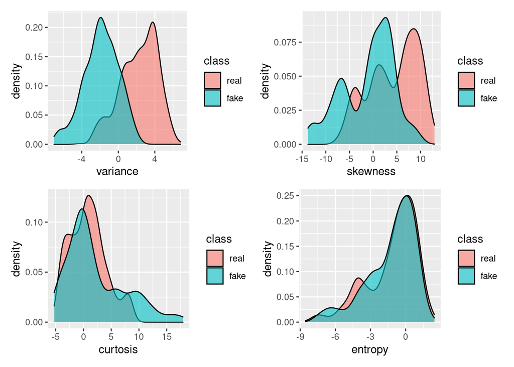

```r
p <- ggplot(data,
            aes(x = variance,
                fill = class)) +
  geom_density(alpha = .6)

q <- ggplot(data,
            aes(x = skewness,
                fill = class)) +
  geom_density(alpha = .6)

r <- ggplot(data,
            aes(x = curtosis,
                fill = class)) +
  geom_density(alpha = .6)

s <- ggplot(data,
            aes(x = entropy,
                fill = class)) +
  geom_density(alpha = .6)

(p + q) / (r + s)
```

We also have a correlation plot to observe the possible existency of multicollinearity.

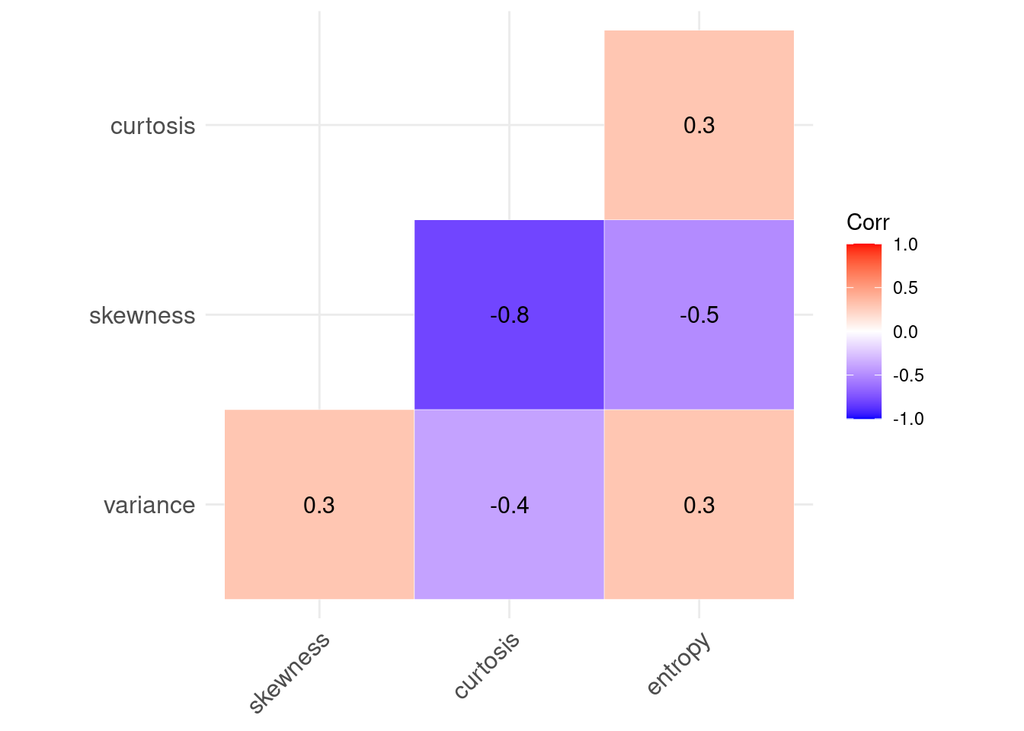

```r
ggcorrplot(round(cor(data[,-5]), 1),
           hc.order = TRUE,
           type = "lower",
           outline.color = "white",
           lab = TRUE)
```

Another important aspect is the proportion of each level of the `class`variable in our data.

```r
data %>%
  count(class) %>%
  mutate(prop = n/sum(n)) %>%
  kbl() %>%
  kable_styling(full_width = FALSE)
```

| class | n | prop |
| --- | --- | --- |
| real | 762 | 0.5553936 |
| fake | 610 | 0.4446064 |

# Models

A few model are considered to the task of classification banknotes.

## Data splitting

Let’s split our data in two sets: training and test. The first one is used when fitting the model parameters. The second one will help to measure the performance of our fitted model.

```r
set.seed(1987)
data_split <- initial_split(data, prop = 3/4)

normalize <- function(x) {
    return ((x - min(x)) / (max(x) - min(x)))
}

train_data <-
  training(data_split) %>%
  mutate_at(c("variance", "skewness", "curtosis", "entropy"),
                                                 ~normalize(.))
test_data <-
  testing(data_split) %>%
  mutate_at(c("variance", "skewness", "curtosis", "entropy"),
                                                 ~normalize(.))
```

### Naive Bayes

```r
banknotes <-
  recipe(class ~ ., data = train_data)

bayes_model <-
  naive_Bayes() %>%
  set_mode("classification") %>%
  set_engine("klaR")

banknotes_wflow <-
  workflow() %>%
  add_model(bayes_model) %>%
  add_recipe(banknotes)

bayes_fit <-
  banknotes_wflow %>%
  fit(data = train_data)
```

```r
bayes_pred <-
  predict(bayes_fit, test_data, type = "prob") %>%
  bind_cols(test_data)

bayes_pred
```

```
## # A tibble: 343 x 7
##    .pred_real .pred_fake variance skewness curtosis entropy class
##         <dbl>      <dbl>    <dbl>    <dbl>    <dbl>   <dbl> <fct>
##  1      0.731 0.269         0.554    0.350   0.431    0.702 real
##  2      0.794 0.206         0.695    0.261   0.601    0.741 real
##  3      0.985 0.0149        0.650    0.869   0.132    0.728 real
##  4      1.00  0.0000994     0.845    0.417   0.336    0.890 real
##  5      0.846 0.154         0.403    0.933   0.342    0.503 real
##  6      0.995 0.00532       0.741    0.637   0.247    0.862 real
##  7      1.00  0.0000324     0.945    0.940   0.0408   0.384 real
##  8      1.00  0.00000793    0.841    0.907   0.0639   0.393 real
##  9      0.900 0.0997        0.647    0.658   0.375    0.852 real
## 10      0.998 0.00176       0.742    0.749   0.211    0.732 real
## # … with 333 more rows
```

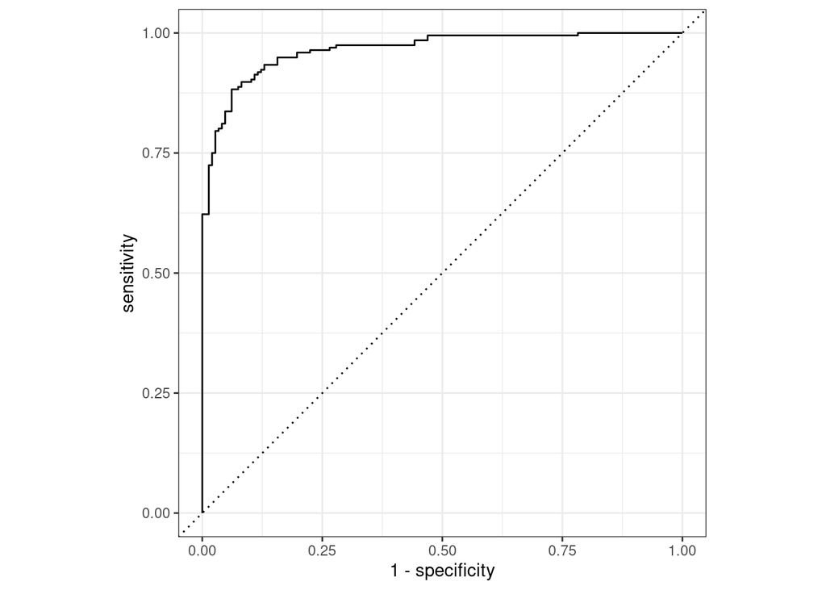

```r
bayes_pred %>%
  roc_curve(truth = class, .pred_real) %>%
  autoplot()
```

```r
bayes_pred %>%
  roc_auc(truth = class, .pred_real)
```

```
## # A tibble: 1 x 3
##   .metric .estimator .estimate
##   <chr>   <chr>          <dbl>
## 1 roc_auc binary         0.965
```

### Logistic Regression

Below we create the recipe for our model and normalize all the variables used to classify the `class` variable.

```r
banknotes <-
  recipe(class ~ ., data = train_data) #%>%
  #step_normalize(all_predictors())

summary(banknotes)
```

```
## # A tibble: 5 x 4
##   variable type    role      source
##   <chr>    <chr>   <chr>     <chr>
## 1 variance numeric predictor original
## 2 skewness numeric predictor original
## 3 curtosis numeric predictor original
## 4 entropy  numeric predictor original
## 5 class    nominal outcome   original
```

Now it’s time to define a model and create a workflow putting together the recipe and model definition.

```r
lr_model <-
  logistic_reg() %>%
  set_engine("glm")

banknotes_wflow <-
  workflow() %>%
  add_model(lr_model) %>%
  add_recipe(banknotes)

lr_fit <-
  banknotes_wflow %>%
  fit(data = train_data)

lr_fit %>%
  pull_workflow_fit() %>%
  tidy() %>%
  kbl() %>%
  kable_styling(full_width = FALSE)
```

| term | estimate | std.error | statistic | p.value |
| --- | --- | --- | --- | --- |
| (Intercept) | 152.864868 | 38.904462 | 3.929237 | 0.0000852 |
| variance | -108.165818 | 27.523230 | -3.929983 | 0.0000850 |
| skewness | -111.144100 | 27.668057 | -4.017055 | 0.0000589 |
| curtosis | -120.768947 | 30.368063 | -3.976841 | 0.0000698 |
| entropy | -8.021468 | 4.405381 | -1.820834 | 0.0686321 |

Above we can see the estimates for the parameters considered in our model. Note that standard error of our estimates are quite great that we desired. This can be a signal for overfitting in our model.

```r
lr_pred <-
  predict(lr_fit, test_data, type = "prob") %>%
  bind_cols(test_data)

lr_pred
```

```
## # A tibble: 343 x 7
##    .pred_real .pred_fake variance skewness curtosis entropy class
##         <dbl>      <dbl>    <dbl>    <dbl>    <dbl>   <dbl> <fct>
##  1      0.976   2.42e- 2    0.554    0.350   0.431    0.702 real
##  2      1.00    1.23e-13    0.695    0.261   0.601    0.741 real
##  3      1.00    2.22e-16    0.650    0.869   0.132    0.728 real
##  4      1.00    2.22e-16    0.845    0.417   0.336    0.890 real
##  5      1.00    2.22e-16    0.403    0.933   0.342    0.503 real
##  6      1.00    2.22e-16    0.741    0.637   0.247    0.862 real
##  7      1.00    2.22e-16    0.945    0.940   0.0408   0.384 real
##  8      1.00    2.22e-16    0.841    0.907   0.0639   0.393 real
##  9      1.00    2.22e-16    0.647    0.658   0.375    0.852 real
## 10      1.00    2.22e-16    0.742    0.749   0.211    0.732 real
## # … with 333 more rows
```

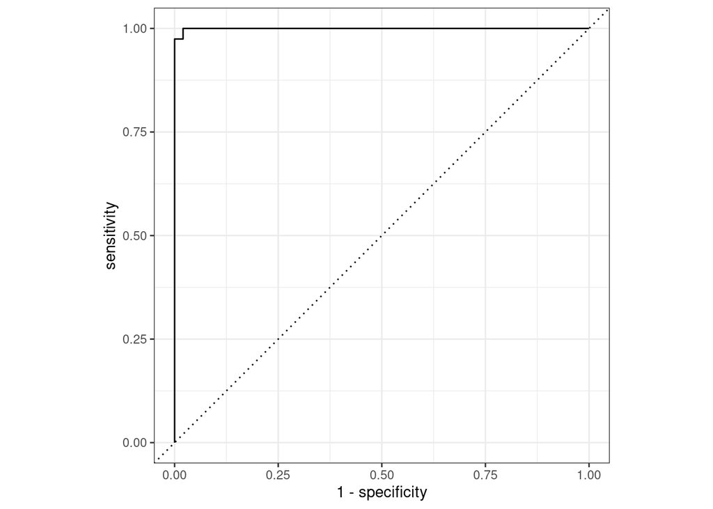

```r
lr_pred %>%
  roc_curve(truth = class, .pred_real) %>%
  autoplot()
```

```r
lr_pred %>%
  roc_auc(truth = class, .pred_real)
```

```
## # A tibble: 1 x 3
##   .metric .estimator .estimate
##   <chr>   <chr>          <dbl>
## 1 roc_auc binary         0.999
```

### Logistic Regression with Regularization

As we saw, our simple logistic model is overfitted. Trying to solve this problem, we are going to use regularization. Also let’s add some new variables created from the original ones.

```r
train_data <-
  train_data %>%
  mutate(variance_square = variance^2,
         skewness_root = sqrt(skewness),
         curtosis_log = log(curtosis),
         entropy_inv = 1/entropy) %>%
  filter(!is.infinite(entropy_inv), !is.infinite(curtosis_log))

test_data <-
  test_data %>%
  mutate(variance_square = variance^2,
         skewness_root = sqrt(skewness),
         curtosis_log = log(curtosis),
         entropy_inv = 1/entropy) %>%
  filter(!is.infinite(entropy_inv), !is.infinite(curtosis_log))

banknotes_reg <-
  recipe(class ~ ., data = train_data) #%>%
  # step_range(all_predictors(), min = 0, max = 1) %>%
  # step_mutate(variance_square = variance^2,
  #             skewness_root = sqrt(skewness),
  #             curtosis_log = log(curtosis),
  #             entropy_inv = 1/entropy) %>%
  # step_filter(!is.infinite(curtosis_log),!is.na(curtosis_log), !is.nan((curtosis_log)),
  #             !is.infinite(skewness_root),!is.na(skewness_root), !is.nan((skewness_root)))

summary(banknotes_reg)
```

```
## # A tibble: 9 x 4
##   variable        type    role      source
##   <chr>           <chr>   <chr>     <chr>
## 1 variance        numeric predictor original
## 2 skewness        numeric predictor original
## 3 curtosis        numeric predictor original
## 4 entropy         numeric predictor original
## 5 variance_square numeric predictor original
## 6 skewness_root   numeric predictor original
## 7 curtosis_log    numeric predictor original
## 8 entropy_inv     numeric predictor original
## 9 class           nominal outcome   original
```

There is also the definition of stratified cross validation for our model due the insertion of a hyperparameter for the regularization.

```r
l_cv <- vfold_cv(train_data, v = 10, strata = "class")

lr_model_reg <-
  logistic_reg() %>%
  set_args(penalty = tune(), mixture = 0) %>%
  set_engine("glmnet") %>%
  set_mode("classification")

banknotes_wflow_reg <-
  workflow() %>%
  add_model(lr_model_reg) %>%
  add_recipe(banknotes_reg)

lr_grid <- expand.grid(penalty = seq(0,10,0.01))

lr_tune_results <- banknotes_wflow_reg %>%
  tune_grid(resamples = l_cv,
            grid = lr_grid,
            metrics = metric_set(accuracy, roc_auc),
            control   = control_grid(verbose = TRUE))
```

```r
lr_tune_results %>%
  collect_metrics()
```

```
## # A tibble: 2,002 x 7
##    penalty .metric  .estimator  mean     n  std_err .config
##      <dbl> <chr>    <chr>      <dbl> <int>    <dbl> <chr>
##  1    0    accuracy binary     0.979    10 0.00452  Preprocessor1_Model0001
##  2    0    roc_auc  binary     1.00     10 0.000215 Preprocessor1_Model0001
##  3    0.01 accuracy binary     0.979    10 0.00452  Preprocessor1_Model0002
##  4    0.01 roc_auc  binary     1.00     10 0.000215 Preprocessor1_Model0002
##  5    0.02 accuracy binary     0.979    10 0.00452  Preprocessor1_Model0003
##  6    0.02 roc_auc  binary     1.00     10 0.000215 Preprocessor1_Model0003
##  7    0.03 accuracy binary     0.979    10 0.00452  Preprocessor1_Model0004
##  8    0.03 roc_auc  binary     1.00     10 0.000215 Preprocessor1_Model0004
##  9    0.04 accuracy binary     0.979    10 0.00452  Preprocessor1_Model0005
## 10    0.04 roc_auc  binary     1.00     10 0.000215 Preprocessor1_Model0005
## # … with 1,992 more rows
```

```r
param_final <-
  lr_tune_results %>%
  select_best(metric = "roc_auc")
param_final
```

```
## # A tibble: 1 x 2
##   penalty .config
##     <dbl> <chr>
## 1       0 Preprocessor1_Model0001
```

```r
banknotes_wflow_reg <-
  banknotes_wflow_reg %>%
  finalize_workflow(param_final)
banknotes_wflow_reg
```

```
## ══ Workflow ════════════════════════════════════════════════════════════════════
## Preprocessor: Recipe
## Model: logistic_reg()
##
## ── Preprocessor ────────────────────────────────────────────────────────────────
## 0 Recipe Steps
##
## ── Model ───────────────────────────────────────────────────────────────────────
## Logistic Regression Model Specification (classification)
##
## Main Arguments:
##   penalty = 0
##   mixture = 0
##
## Computational engine: glmnet
```

```r
lr_fit_reg <-
  banknotes_wflow_reg %>%
  fit(data = train_data)

lr_fit_reg %>%
  pull_workflow_fit() %>%
  tidy() %>%
  kbl() %>%
  kable_styling(full_width = FALSE)
```

| term | estimate | penalty |
| --- | --- | --- |
| (Intercept) | 8.8316295 | 0 |
| variance | -5.9882590 | 0 |
| skewness | -3.7994754 | 0 |
| curtosis | -3.4175062 | 0 |
| entropy | 1.0405663 | 0 |
| variance_square | -5.0573508 | 0 |
| skewness_root | -4.3220243 | 0 |
| curtosis_log | -0.9632711 | 0 |
| entropy_inv | -0.0720771 | 0 |

```r
lr_pred_reg <-
  predict(lr_fit_reg, test_data, type = "prob") %>%
  bind_cols(test_data)

lr_pred_reg
```

```
## # A tibble: 341 x 11
##    .pred_real .pred_fake variance skewness curtosis entropy class
##         <dbl>      <dbl>    <dbl>    <dbl>    <dbl>   <dbl> <fct>
##  1      0.492    0.508      0.554    0.350   0.431    0.702 real
##  2      0.864    0.136      0.695    0.261   0.601    0.741 real
##  3      0.915    0.0852     0.650    0.869   0.132    0.728 real
##  4      0.970    0.0302     0.845    0.417   0.336    0.890 real
##  5      0.867    0.133      0.403    0.933   0.342    0.503 real
##  6      0.949    0.0507     0.741    0.637   0.247    0.862 real
##  7      0.997    0.00261    0.945    0.940   0.0408   0.384 real
##  8      0.991    0.00913    0.841    0.907   0.0639   0.393 real
##  9      0.937    0.0631     0.647    0.658   0.375    0.852 real
## 10      0.972    0.0283     0.742    0.749   0.211    0.732 real
## # … with 331 more rows, and 4 more variables: variance_square <dbl>,
## #   skewness_root <dbl>, curtosis_log <dbl>, entropy_inv <dbl>
```

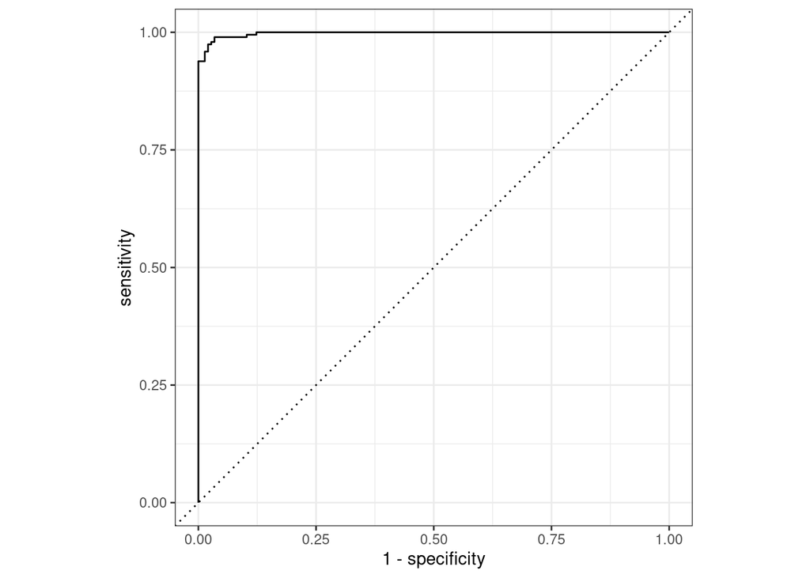

```r
lr_pred_reg %>%
  roc_curve(truth = class, .pred_real) %>%
  autoplot()
```

```r
lr_pred_reg %>%
  roc_auc(truth = class, .pred_real)
```

```
## # A tibble: 1 x 3
##   .metric .estimator .estimate
##   <chr>   <chr>          <dbl>
## 1 roc_auc binary         0.998
```